# Inside the 2024 NFL Season

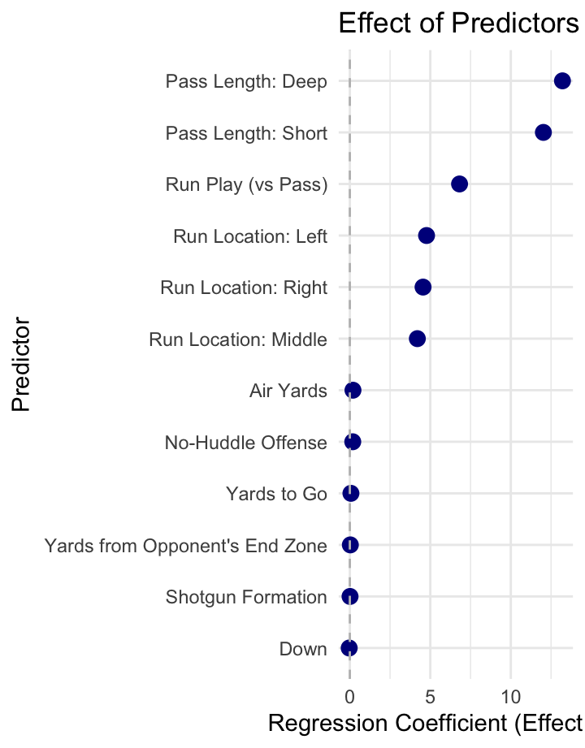

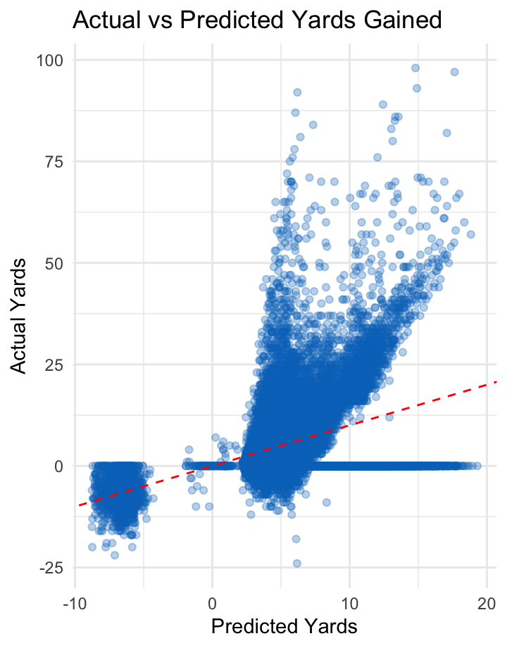

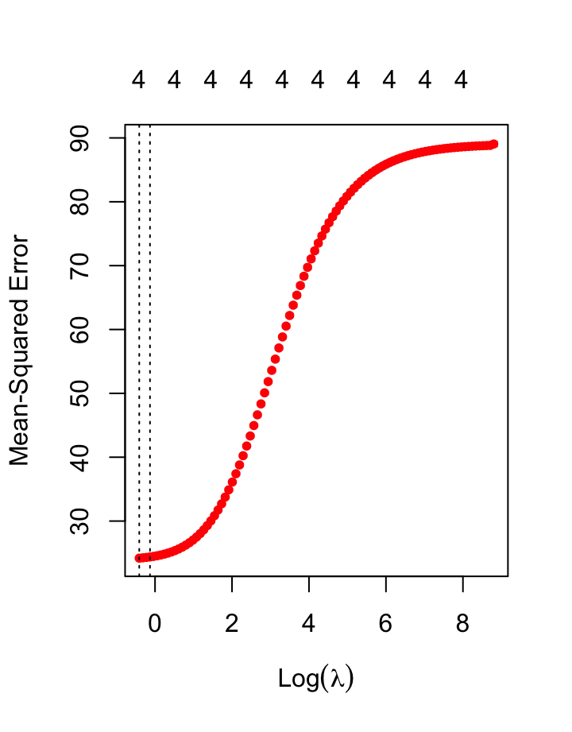

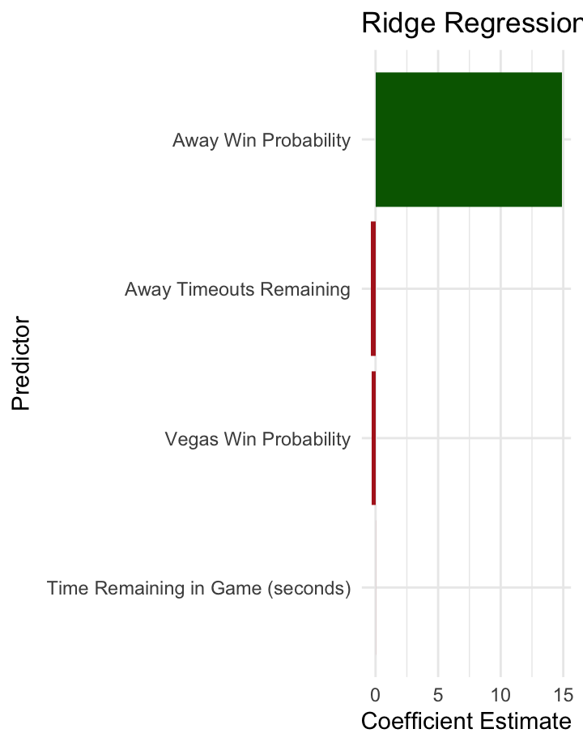

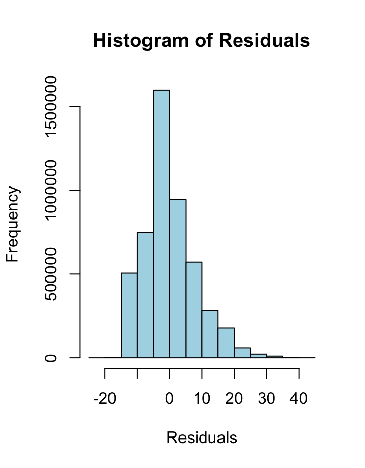

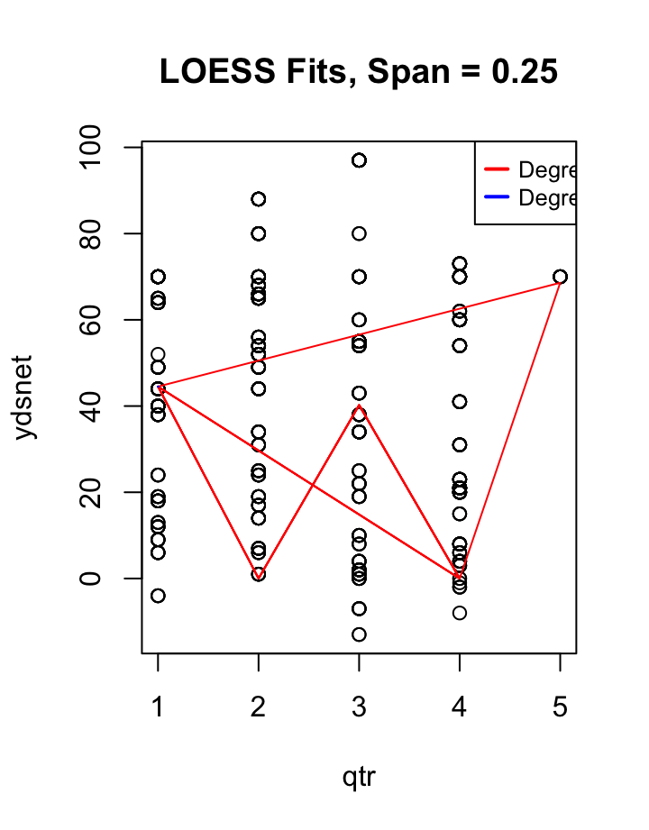

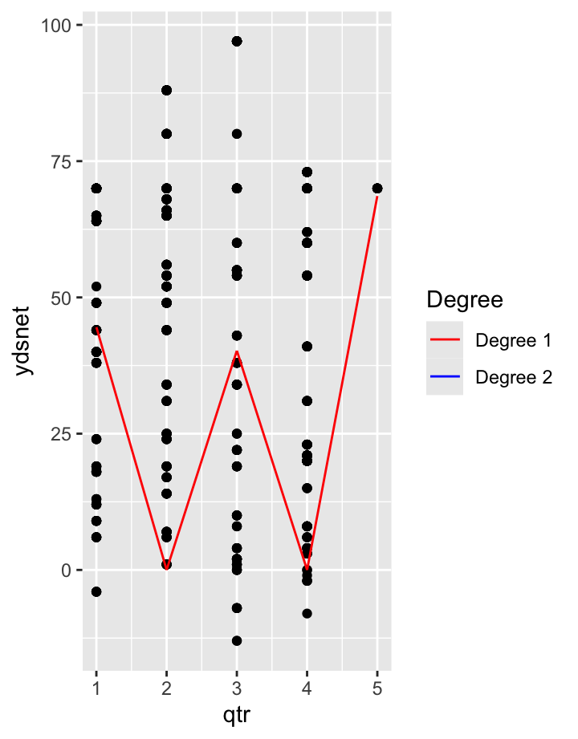

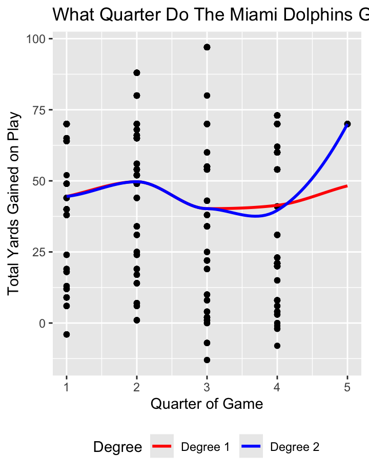

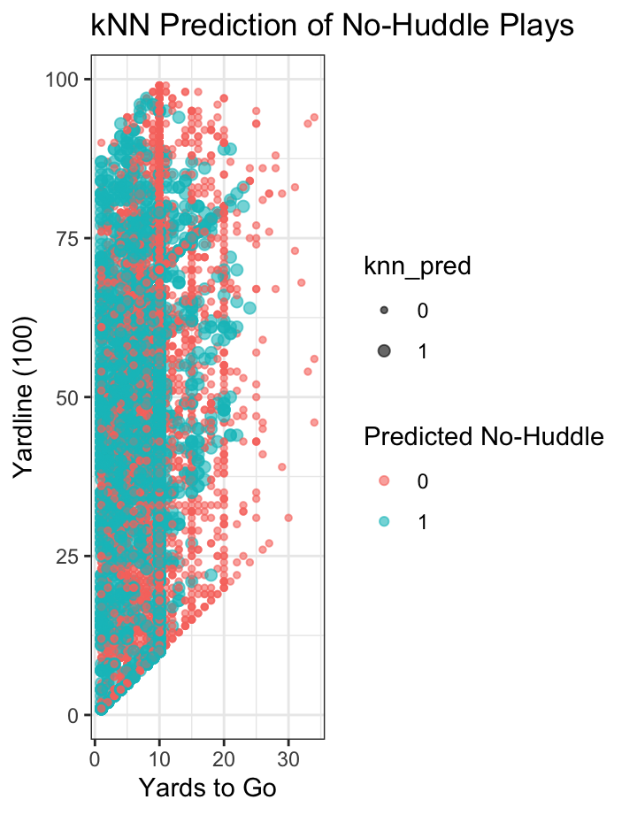

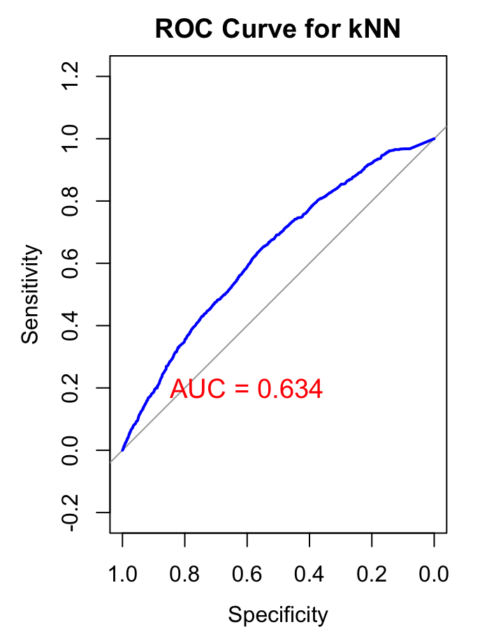

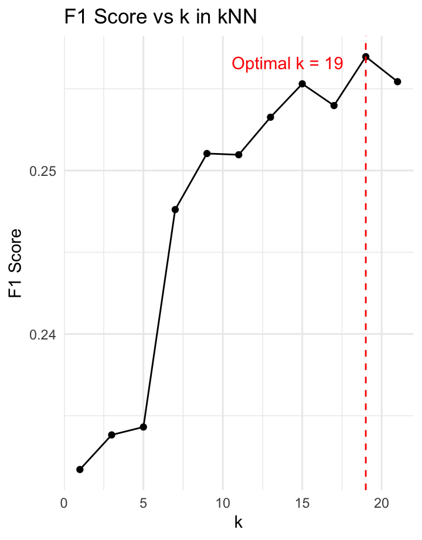

[figure not shown]

[2 more figures not shown]

# Introduction

### Our Motivation

This project is a deep dive into the 2024 NFL play-by-play (PBP) dataset, using statistical modeling and machine learning to answer targeted questions about in-game decisions and outcomes. Football is a sport defined by strategy, context, and quick decision-making, and the PBP dataset offers an in-depth look at how each play unfolds. By analyzing this data through the lens of data science, we can go beyond box scores and uncover patterns that are not immediately visible to casual viewers or even analysts relying on summary statistics.

The motivation behind this project lies in the intersection of sports analytics and decision science. We specifically want to find out how data can be used to better understand team behavior, performance trends, and variables that drive success on the field. The goal is to explore how contextual features, such as field position, formation, down, and distance, effect what happens on the field and how teams operate under different conditions. In doing so, this work aims to both model predictive outcomes and interpret the football logic behind them.

### Our Dataset

The dataset used in this project is the 2024 NFL play-by-play (PBP) data, freely available to the public through the nflfastR project on GitHub. Maintained by the open-source community at NFLverse, this resource provides detailed, structured data for every play of every game in a given NFL season. The data includes hundreds of features such as down, distance, field position, formation (shotgun, no-huddle), air yards, play type, and game context (score differential, quarter, time remaining, etc.). The open-access nature of this dataset makes it a powerful tool for both academic research and inspiring sports analysts, enabling reproducibility and encouraging deeper exploration into football strategy, decision-making, and performance trends.  
nflfastR: https://www.nflfastr.com/  
Data used (before cleaning): https://docs.google.com/spreadsheets/d/1W-xvFfUsyoXWaaRQUV4EQI67zYdoxmIJcSsl2JskdD0/edit?usp=sharing

### Data Dictionary

- **game_id**: Unique identifier for the game (includes season and game code).
- **play_id**: Unique identifier for the play within the game.
- **week**: NFL week number (1–18 regular season, 19+ for postseason).
- **home_team**: Abbreviation for the home team (e.g., “KC”, “BUF”).
- **away_team**: Abbreviation for the away team.
- **posteam**: Team in possession of the ball during the play.
- **posteam_type**: Indicates whether the posteam is the “home” or “away” team.
- **defteam**: Defensive team on the play.
- **yardline_100**: Distance from the end zone the offense is driving toward (1 = 1 yard from end zone, 100 = own 1-yard line).
- **game_half**: Indicates “Half1” or “Half2” (first or second half of the game).
- **drive**: Drive number within the game.
- **qtr**: Quarter of the game (1 through 5; 5 = overtime).
- **down**: Current down (1 to 4), or NA if not applicable.
- **play_type**: Type of play (e.g., “run”, “pass”, “punt”, “field_goal”, “no_play”).
- **time**: Time remaining in the quarter (MM:SS format).
- **ydstogo**: Yards needed for a first down.
- **no_huddle**: TRUE if the offense used a no-huddle approach.
- **air_yards**:Distance the ball traveled in the air from the line of scrimmage (pass plays only).
- **yards_gained**: Net yards gained on the play.
- **epa**: Expected Points Added — change in expected points resulting from the play.
- **success**: TRUE if the play was successful (based on down-and-distance logic).
- **goal_to_go**: TRUE if the offense is in a goal-to-go situation.
- **shotgun**: TRUE if the play started in shotgun formation.
- **run_location**: Side of the field the run was directed to (“left”, “middle”, “right”); only for run plays.
- **pass_length**: Length category of the pass (“short”, “deep”); only for pass plays.
- **ydsnet**: Net yards gained by the offense so far in the game (cumulative).

This Dashboard was created by Group 13, consisting of Paige Gray, Julia Nuckols, and Quinn Apostolico. Paige completed the Introduction, k-Nearest Neighbors, and Logisitc Regression. Julia completed the LOESS fit and Naive Bayes. Quinn completed the Multiple Regression and Ridge Regression.

# Multiple Regression

### The Problem

In football, gaining yards on a play is critical to a team’s success, with outcomes being affected by a complex mix of strategic decisions and situational factors. Coaches, analysts, and data scientists seek understanding in how specific in-game choices impact the number of yards gained. As such, training on real play-by-play data from the 2024 NFL season, this analysis focuses on the following key question:

How do factors like shotgun formation, no-huddle offense, play type, down, distance to go, field position, air yards, run location, and pass length affect the number of yards gained on a play?

Understanding the influence of these variables can provide valuable insight in play-calling effeciency, situational strategy, and general player performance. For example, does a shotgun formation or no-huddle offense typically result in more yardage? How does field position or distance to go affect expected yardage gained? By applying a multiple regression model to this large dataset of play-by-play data, we aim to quantify the relationship between these factors and the outcome variable (yards gained). This can help inform better tactical decisions, optimize play selection, and improve predictive modeling for football analytics.

### Multiple R-squared

[1] “Multiple R-squared: 0.157456419321372”

### Analysis of Results

The examined variables include whether a shotgun formation was used, whether the team played a no-huddle offense, play type (run or pass), down, yards to go for a first down or score, yards from opponent’s end zone, air yards, run locations (left, middle, and right) and pass lengths (deep and short). Multiple regression analysis was performed to assess the statistical significance of these variables in predicting the yards gained on a play. The variables that demonstrated the most significant relationship with yards gained are play type, distance from opponent’s end zone, air yards, and pass length. Additionally, other variables that showed a slightly less significant, but still statistically significant relationship with yards gained include yards to go and run location. Variables that do not show a statistically significant relationship with yards gained include shotgun formations, no-huddle offense, and down. As per the table of coefficients and coefficient plot, the statistically significant intercept of -8.73 indicates that if all of the indicator variables are equal to 0, then there is a baseline expected loss of 8.73 yards on average. Furthermore, run plays gain on average 6.82 yards more than pass plays, holding other variables constant. Additionally, each additional yard needed for a first down or score increases the total yards by 0.07 on average, and each yard from the opponent’s end zone increases the total yards gained by 0.03. Each additional air yard on average increases the total yards gained by 0.2. A left run on average increases by 4.77 yards, a middle run by 4.19 yards, and a right run by 4.55 yards. Finally, a deep pass on average increases the total yards gained by 13.21, while a short pass increases by 12.02. Additionally, the Multiple R-squared value of 0.157 indicates that approximately 15.7% of the variability in yards gained on a play is explained by the predictors in the model, which can likely be explained by the often-noisy nature of real-world sports data, which tends to have a lot of random variation. This indicates that the model is finding statistically significant relationships, but they don’t yet account for most of the variance in outcomes, illustrating it can be useful to understand directional trends (i.e. deep passes generally gain more yards), but one should be cautious of making precise numerical predictions.

### Model Coefficients

| Predictor | Estimate | Std. Error | p Value |
| --- | --- | --- | --- |
| Shotgun Formation | 0.013 | 0.103 | 0.90 |
| No-Huddle Offense | 0.182 | 0.13 | 0.16 |
| Run Play (vs Pass) | 6.817 | 0.735 | < 1e-16 |
| Down | -0.039 | 0.057 | 0.50 |
| Yards to Go | 0.068 | 0.012 | 8.9e-09 |
| Yards from Opponent's End Zone | 0.032 | 0.002 | < 1e-16 |
| Air Yards | 0.195 | 0.009 | < 1e-16 |
| Run Location: Left | 4.767 | 0.711 | 2.1e-11 |
| Run Location: Middle | 4.194 | 0.715 | 4.5e-09 |
| Run Location: Right | 4.549 | 0.712 | 1.7e-10 |

[output cut: 2 more lines]

### Effects of Each Coefficient

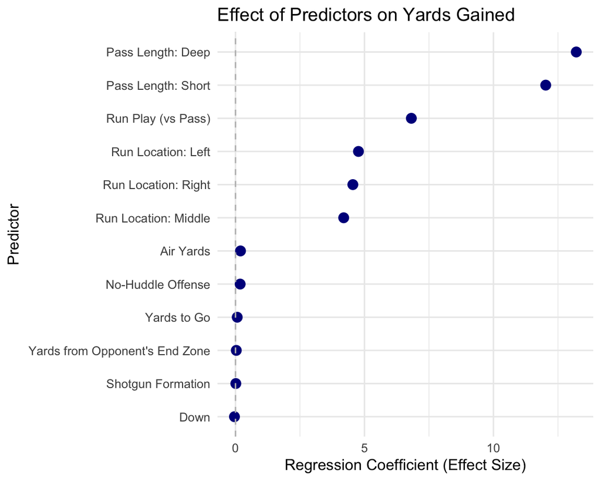

### Model Accuracy Plot

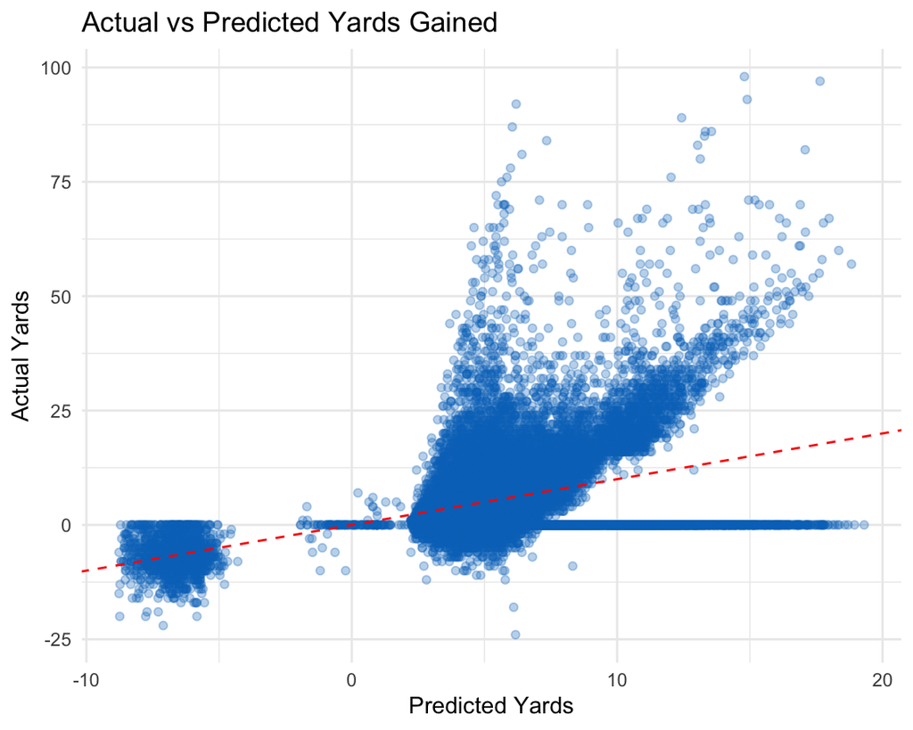

### Model Performance

By plotting the predicted yardage against the actual yardage in the above scatterplot, we can visualize our multiple regression model’s accuracy for predicting the number of yards gained on a football play. We plot the predicted yardage on the x-axis and the actual yardage on the y-axis. A perfect performance is indicated by every point falling exactly on the diagonal reference line, $y=x$, indicating that every prediction perfectly matches the actual value. The closer the points are to this line, the better this model performs. We observe that there is a cluster of points in the bottom left below $y=0$, indicating a group of plays where the model predicted negative yards, and the actual yards gained were even more negative. These are likely to be failed or tackled-behind-the-line plays, such as sacks or runs stopped early. While the model recognizes these as low-gain plays, it may underestimate how severe the loss is. We also observe that there is a line of points along the $y=0$ line, which reflects cases where the actual yards gained is 0, regardless of the model’s prediction. This could indicate incomplete passes, failed conversions, or plays where no ground was gained. The majority of the points are generally spread in the $y=x$ direction, with the two aforementioned clusters likely affecting the skew of points falling generally above the $y=x$ line. This suggests that the model overall does a reasonable job at predicting yards gained, however the spread suggests the aforementioned clusters impacting the predictive accuracy, and the increased spread for higher-yard plays suggests the model struggles with long-yardage predictions, potentially indicating the presence of nonlinear effects or rare events that aren’t well captured by these predictors.

# Ridge Regression

### The Problem

The goal of this analysis is to develop a predictive model to forecast the total number of points scored by the way team during an NFL game using in-game situational features. More specifically, we use ridge regression to model the relationship between the away team’s total score and predictors including the away win probability, number of away timeouts remaining, time reamining in game, and Vegas win probability. By applying regularization through ridge regression, we aim to mitigate potential multicollinearity among predictors to prevent overfitting. This model is trained on real play-by-play data from the 2024 NFL season, and performance is evaluated using mean squared error (MSE) and residual diagnostics. Ultimately, this model seeks to capture how such situational factors influence scoring outcomes for the away team.

### Model Coefficients

| Predictor | Estimate | Std. Error |
| --- | --- | --- |
| Away Win Probability | 14.8703 | NA |
| Away Timeouts Remaining | -0.352 | NA |
| Time Remaining in Game (seconds) | -0.0058 | NA |
| Vegas Win Probability | -0.3055 | NA |

### Mean Squared Error

[1] “Mean Squared Error: 62.7585742169048”

### Coefficient Magnitude Bar Plot

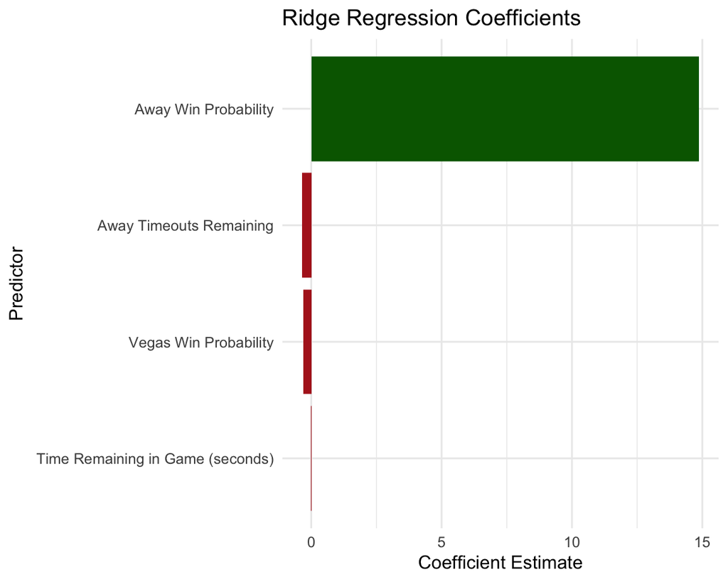

### Histogram of Residuals

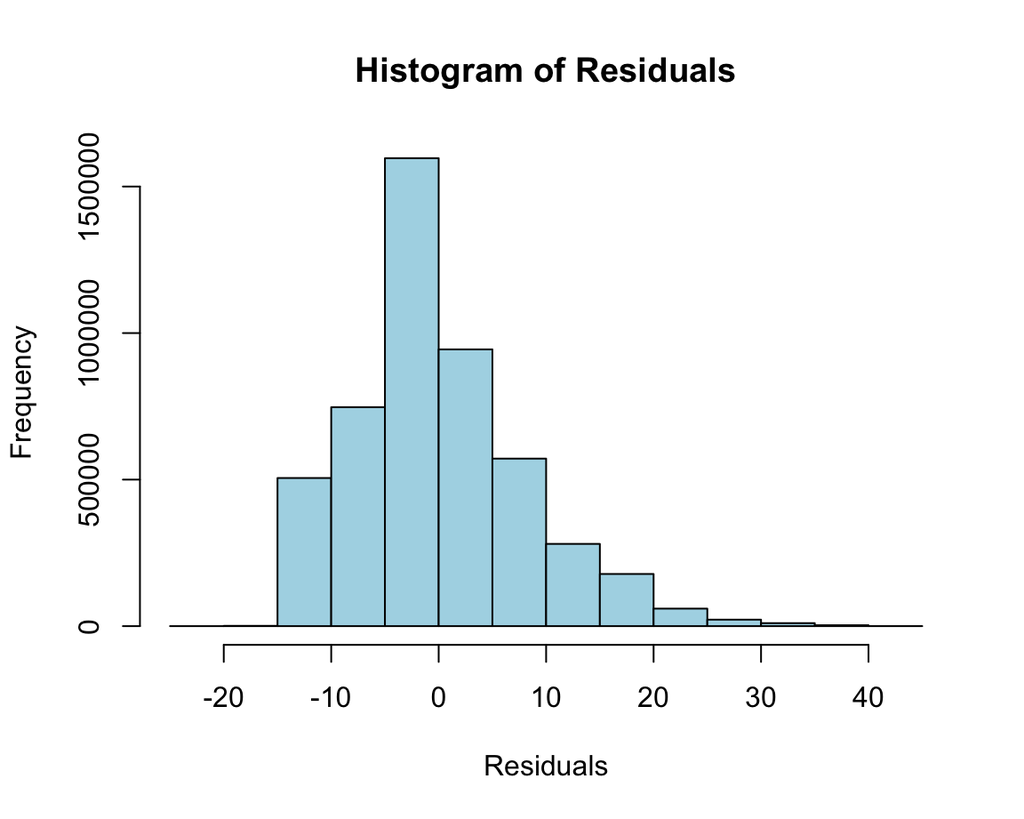

# LOESS Fit

## Column {data-width = 400}

### The Question

Each quarter of a football game is 15 minutes long, with there being 4 quarters in each game. Now this doesn’t include overtime or all the the timeouts. On average, an NFL game lasts around 3 hours and 12 minutes. With games being this long can they keep the adrenline up the whole time or do they start to get tired? A run is one of the most critical plays during a game since each run the team is getting closer and closer to the end zone. This led to my research question.

Do the Miami Dolphins run more yards in the beginning of the game or the end?

I explored this question by using LOESS fit to fit a smooth curve across quarter and total yard gained on a given drive.

### LOESS fit with Span = 0.25

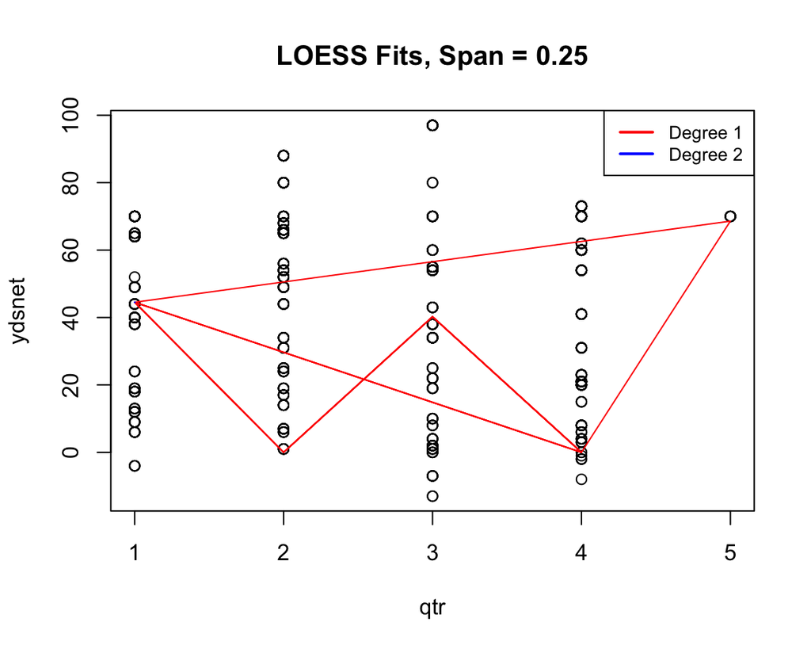

### LOESS Fit Before Smoothing

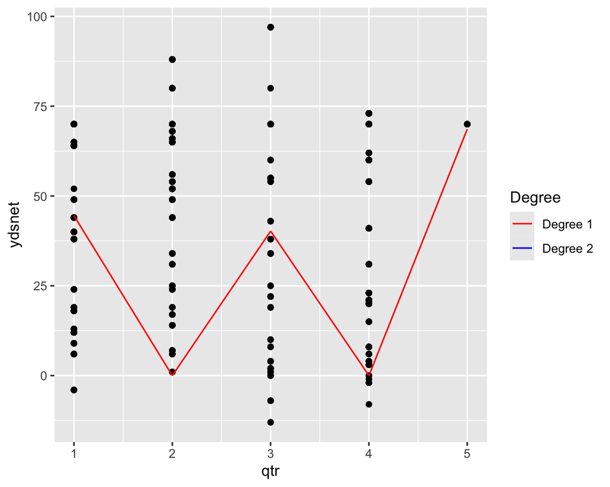

### LOESS Fit After Smoothing to Span = 0.7

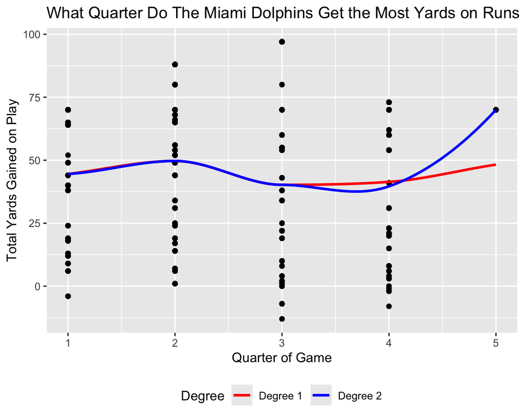

### LOESS Performance

Due to the high variance and noise of this data, LOESS failed to identify a clear underlying trend. However, we can still look at the graph to see some result. With the smoothed LOESS fit with span = 0.7 we can see that the second quarter produced the most yards ran on plays. The graph also gets a little confused since there was a couple fifth quarter outliers meaning that game went into overtime. While LOESS can be a very effective fit for certain types of data, it did struggle with this data set most likely because these two variables don’t neccessarily correlate well together. As you can see I fit the LOESS curve using base R and also fit the LOESS curve using ggplot. These produced two different visualizationg that we can compare. The Base R has a span of 0.25 while the ggplot fit has a span of 0.7.

### Advantages and Disadvantages

Some disadvantages of using LOESS fit is that it is very sensitive to the parameters chosen, span, degree, etc. Any small tweak can immensely change how the visualization looks. LOESS is also pretty difficult to work with when using a large data set, especially when there is outliers since it is very sensitive to that. However, LOESS is pretty adaptive to pattern which works well for data sets with varying complexities. Also, although noise can be a factor to why LOESS can fail, in a lot of cases LOESS can effectively reduce noise in the data set.

# k-Nearest Neighbors

### The Problem

Offensive tempo in football can significantly impact game strategy, defensive fatigue, and play success. One indicator of an up-tempo offense is the no-huddle play, where the offense does not pause to huddle between plays. Understanding the contextual factors that lead to a team choosing a no-huddle approach can inform both predictive analytics and game planning. This led to the following research question:

Can we predict whether a play is part of a no-huddle offense based on contextual variables such as down, yards to go, quarter, and field position?

To explore this, I used a k-Nearest Neighbors (kNN) classification model to classify whether a given play was part of a no-huddle sequence. The goal was to evaluate how well basic game context features could identify a team’s decision to use no-huddle, offering insight into offensive tendencies.

### Model Predicitions

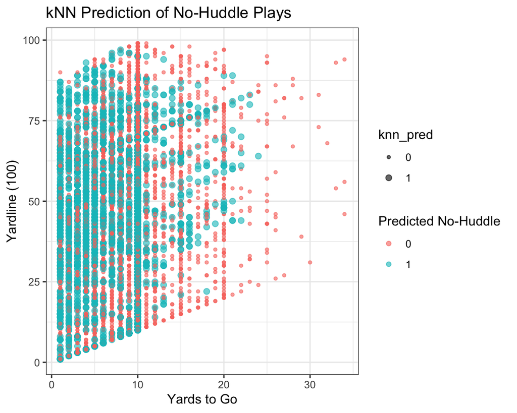

### Confusion Matrix for kNN Predictions

[output not shown]

### ROC Curve

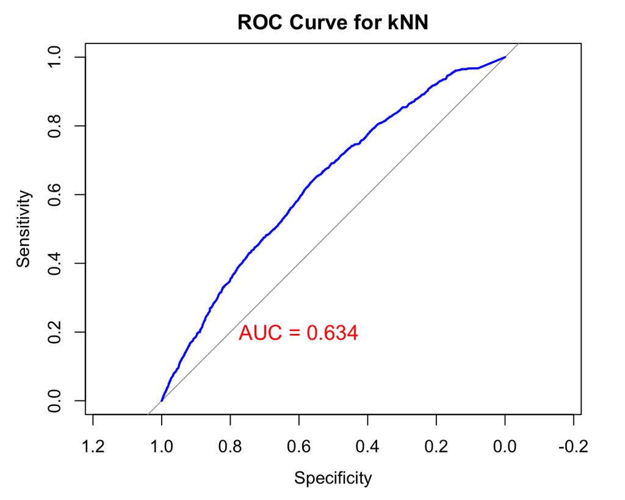

### Finding the optimal K value

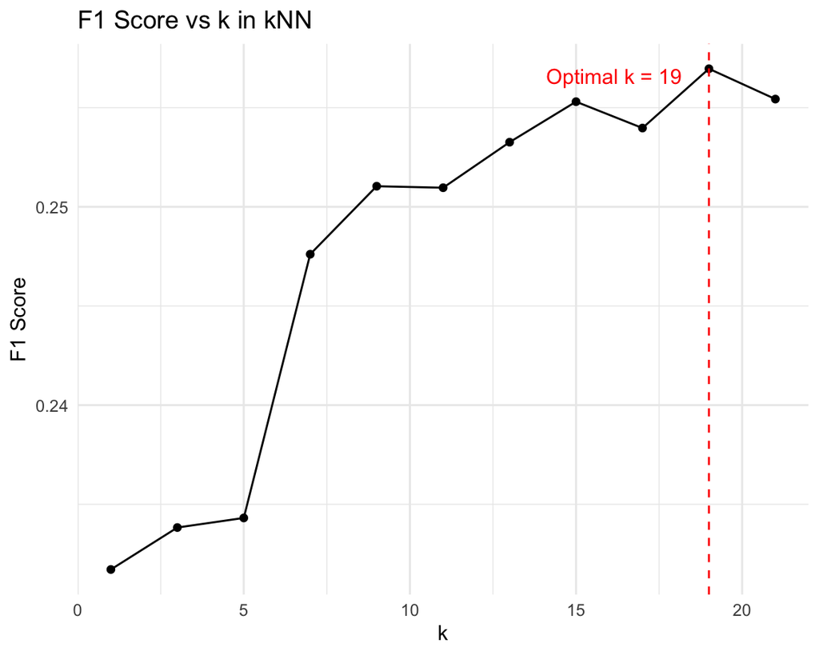

### Model Performance

These kNN results highlight some important nuances in evaluating the performance of our model. Initially, we compared models using overall accuracy, but this proved misleading—since the majority class (no-huddle = 0) dominates and we could only achieve high prediction accuracy in the majority class. To address this, we pivoted to using F1 score, which balances precision and recall, and found it is more appropriate when detecting a minority class (no-huddle = 1).

Using F1 as the metric, we identified the optimal number of neighbors (k). The model’s performance improved when we balanced the training data through oversampling, allowing it to better capture patterns associated with no-huddle plays.

# Naive Bayes

### The Question

In the NFL when a play is made that either causes the home or away team to have possession of the ball. The first 2 weeks of the games can be the most exciting and nerve wracking time of these players careers. Hundreds of plays can be made in just one game, so I wanted to see how often in week 1 and week 2 does each play result in the home team having possession of the ball compared to the away team. Do these home teams thrive or crumble under the pressure of playing in their home stadium for the first time of the season?

### Summary of Naive Bayes

```
          Length Class  Mode
apriori   2      table  numeric
tables    4      -none- list
levels    2      -none- character
isnumeric 4      -none- logical
call      4      -none- call
```

### Simple Table

```
      playTestY
yhat   away home
  away  262   66
  home   83  309
```

## Columns {data-width = 300}

### Confusion Matrix

Confusion Matrix with Row and Column Totals

|  | away | home | Row Total |
| --- | --- | --- | --- |
| away | 262 | 66 | 328 |
| home | 83 | 309 | 392 |
| Column Total | 345 | 375 | 720 |

### Confusion Matrix Heat Map

[figure not shown]

### Why Naive Bayes

Naive Bayes classification model uses strong independence assumptions about the chosen predictors in the model. Although these are large assumptions, Naive Bayes classifier can be used in many applications. Since it is most useful for classification tasks such as predicting game outcomes, I want to see if it can predict which team will have possession.

### Misclassification Rate

```
The misclassification rate is
: 0.2069444
```

This means that the model predicts about 20.7% or 1 in 5 cases incorrectly. Some things in this model or the data set could’ve hindered the accuracy of the Naive Bayes. These could be things such as noise in the data set or the distribution.

# Logistic Regression

### The Problem

Gaining a first down is one of the most critical outcomes of any offensive play in football, directly impacting drive success and scoring opportunities. Predicting whether a play results in a first down can provide valuable insight into team strategy and play efficiency. Various contextual variables, such as the down, distance to the next first down, air yards, and field position can influence the likelihood of converting.

This led to the following research question: Can we predict whether a play will result in a first down based on basic game context variables like down, yards to go, air yards, and field position?

To explore this question, I used a logistic regression model to classify whether a play gained a first down. The model aimed to evaluate how well simple, widely-available play-by-play features could predict successful conversions, offering a foundation for deeper insights into offensive decision-making and efficiency.

### Density plot of Probabilities

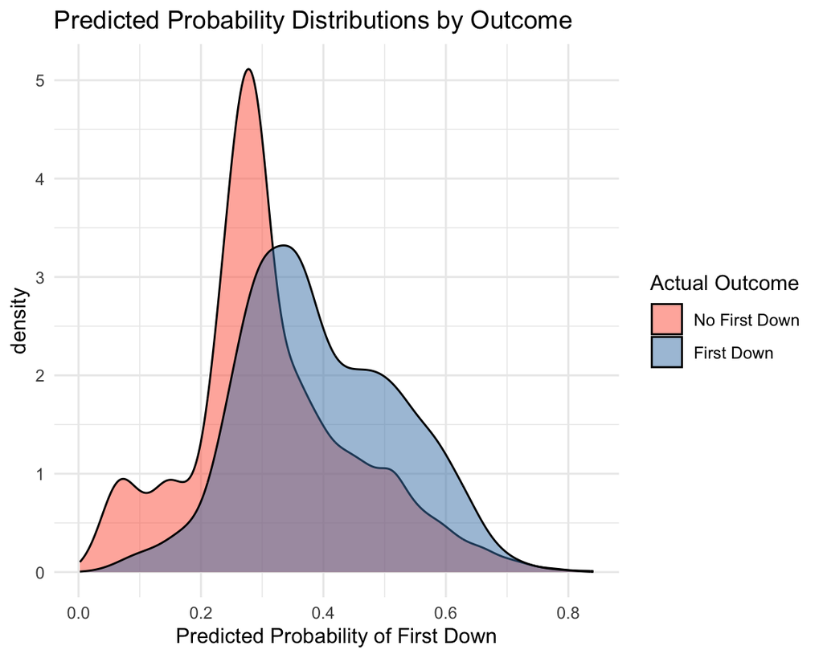

### Model Accuracy Plot

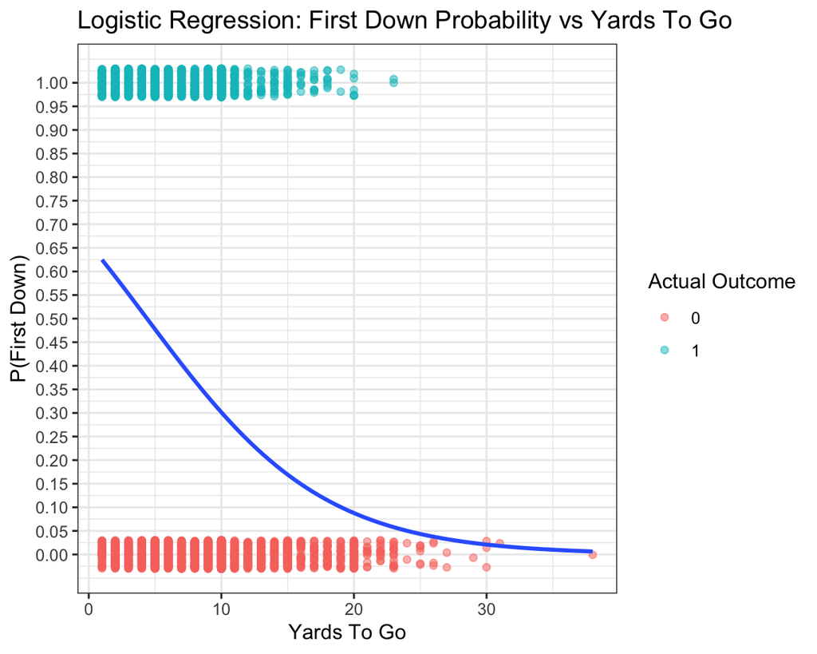

### Model Performance

The Density plot (left) visualizes the predicted probability distributions of achieving a first down for both classes (no first down and first down) based on the logistic regression model. By plotting the predicted probabilities on the x-axis and differentiating the two outcomes with colors, the plot highlights how well the model separates the two classes. Since the two curves overlap significantly, the model struggles to distinguish between the classes effectively. However, from the graph, we can see that the model is better at identifying situations where teams are unlikely to achieve a first down, particularly in extreme cases (very low or high predicted probabilities). This suggests that while the model performs poorly in many cases, it does capture some clear instances where the outcome is more predictable.

The Accuracy plot (above) explores the relationship between the number of yards to go (ydstogo) and the predicted probability of a first down (P(First Down)), showing the logistic regression model’s prediction for different values of ydstogo. A scatter plot of actual outcomes is overlaid with a fitted logistic regression curve, which illustrates how the probability of getting a first down changes as the yards to go increases. The model performs reasonably well in short-yardage situations, where first downs are more predictable. However, the noticeable overlap and scattering of outcomes suggest that other contextual factors not included in the model may be influencing the result.

### Model Coefficients

| Predictor | Estimate | Std. Error | p Value |
| --- | --- | --- | --- |
| down | -0.058 | 0.026 | 0.025 |
| ydstogo | -0.173 | 0.007 | < 1e-16 |
| air_yards | 0.025 | 0.002 | < 1e-16 |
| yardline_100 | 0.004 | 0.001 | 4.6e-06 |

### Confusion Matrix for Logistic Regression Predictions

| Predicted | Actual | Freq | Prediction Status |
| --- | --- | --- | --- |
| No First Down | No First Down | 3087 | Correct |
| First Down | No First Down | 388 | Incorrect |
| No First Down | First Down | 1419 | Incorrect |
| First Down | First Down | 428 | Correct |